# Population and Economic Effects of Storm Damage

RP

3/1/2021

## Synopsis:

The data available from the U.S. National Oceanic and Atmospheric Administration’s (NOAA) storm database was downloaded and analyzed to determine what types of storms have the most effect on human health and cause the most economic destruction. Through very little data processing and simple exploratory bar graphs conclusions can be made. Tornadoes are shown to be the leading cause of injury and death due to storm while floods cause the most economic damage to both property and agriculture.

## Data Processing for Question 1:

### Across the United States, which types of events are most harmful with respect to population health?

```r
pophealth <- stormdata %>% select(EVTYPE, FATALITIES, INJURIES)
## Combine the columns and filter out the zeroes
harmed <- pophealth %>% select(EVTYPE, FATALITIES, INJURIES) %>% mutate(HARMED = FATALITIES + INJURIES) %>% filter(HARMED != 0)
## Aggregate totals by the event type
harmed <- aggregate(cbind(FATALITIES, INJURIES, HARMED) ~ EVTYPE, data = harmed, FUN = sum)
## Arrange by total harmed, then by most fatalities
harmed <- arrange(harmed, desc(HARMED, FATALITIES))
## Plot the top ten?
harmed10 <- harmed[1:10,]
harmed10
```

```
##               EVTYPE FATALITIES INJURIES HARMED
## 1            TORNADO       5633    91346  96979
## 2     EXCESSIVE HEAT       1903     6525   8428
## 3          TSTM WIND        504     6957   7461
## 4              FLOOD        470     6789   7259
## 5          LIGHTNING        816     5230   6046
## 6               HEAT        937     2100   3037
## 7        FLASH FLOOD        978     1777   2755
## 8          ICE STORM         89     1975   2064
## 9  THUNDERSTORM WIND        133     1488   1621
## 10      WINTER STORM        206     1321   1527
```

## Results for Question 1:

Produced a bar graph showing the storm events that caused the top ten greatest amount of injury and death to the US population. Tornadoes clearly lead with their destruction.

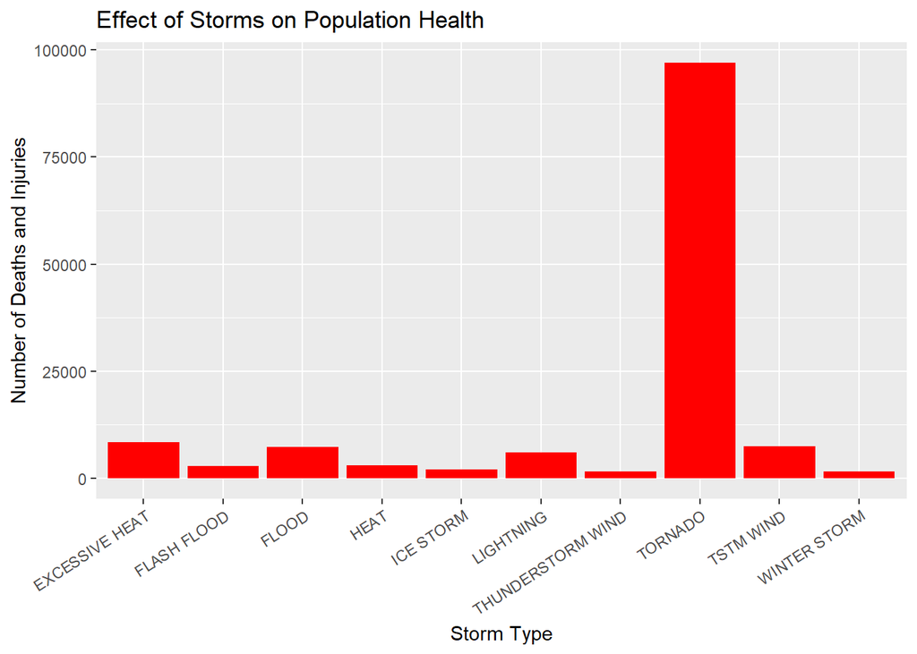

```r
ggplot(harmed10, aes(x = EVTYPE, y = INJURIES + FATALITIES)) + geom_bar(position = "stack", stat = "identity", fill = "red") + labs(title = "Effect of Storms on Population Health", x = "Storm Type", y = "Number of Deaths and Injuries") + theme(axis.text.x=element_text(angle=33, hjust = 1))
```

## Data Processing for Question 2:

### Across the United States, which types of events have the greatest economic consequences?

```r
#Relevant columns are Property Damages and Crop Damages.
#Both Damages have two columns: one with "value" and one an "exponent", where M = millions and K = thousands
economy <- stormdata %>% select(EVTYPE, PROPDMG, PROPDMGEXP, CROPDMG, CROPDMGEXP)
## Change letter suffixes in EXP to numeric multipliers of DMG
economy$CROPDMGEXP <- gsub("k", "1000", economy$CROPDMGEXP, ignore.case = TRUE)
economy$CROPDMGEXP <- gsub("m", "1000000", economy$CROPDMGEXP, ignore.case = TRUE)
economy$PROPDMGEXP <- gsub("k", "1000", economy$PROPDMGEXP, ignore.case = TRUE)
economy$PROPDMGEXP <- gsub("m", "1000000", economy$PROPDMGEXP, ignore.case = TRUE)
## Noticed some other modifiers while scrolling through the data...
## Find out what they are
table(economy$PROPDMGEXP)
```

```
##
##               -       ?       +       0       1    1000 1000000       2       3
##  465934       1       8       5     216      25  424665   11337      13       4
##       4       5       6       7       8       B       h       H
##       4      28       4       5       1      40       1       6
```

```r
##Make them disappear
##All weird ones are just changed to identity multiplier of "1"
economy$PROPDMGEXP <- gsub("h", "100", economy$PROPDMGEXP, ignore.case = TRUE)
economy$PROPDMGEXP <- gsub("b", "1000000000", economy$PROPDMGEXP, ignore.case = TRUE)
economy$PROPDMGEXP <- gsub("\\-|\\?|\\+|2|3|4|5|6|7|8|9", "1", economy$PROPDMGEXP, ignore.case = TRUE)
table(economy$CROPDMGEXP)
```

```
##
##               ?       0    1000 1000000       2       B
##  618413       7      19  281853    1995       1       9
```

```r
economy$CROPDMGEXP <- gsub("b", "1000000000", economy$CROPDMGEXP, ignore.case = TRUE)
economy$CROPDMGEXP <- gsub("\\?|2", "1", economy$CROPDMGEXP, ignore.case = TRUE)

economy$CROPDMGEXP <- as.numeric(economy$CROPDMGEXP)
economy$PROPDMGEXP <- as.numeric(economy$PROPDMGEXP)
```

```r
##Combine the DMG and EXP columns

eco <- economy %>% mutate(PROP = PROPDMG * PROPDMGEXP, CROP = CROPDMG * CROPDMGEXP)
ecodmg <- aggregate(cbind(PROP, CROP) ~ EVTYPE, data = eco, FUN = sum)
ecodmg$TOTAL <- ecodmg$PROP + ecodmg$CROP
ecodmg <- arrange(ecodmg, desc(TOTAL))
ecodmg10 <- ecodmg[1:10,]
ecodmg10
```

```
##               EVTYPE         PROP       CROP        TOTAL
## 1              FLOOD 132836489050 5170955450 138007444500
## 2  HURRICANE/TYPHOON  26740295000 2607872800  29348167800
## 3            TORNADO  16166946690  403379460  16570326150
## 4          HURRICANE   9716358000 2688910000  12405268000
## 5        RIVER FLOOD   5079635000 5028734000  10108369000
## 6               HAIL   7991788720 2053807900  10045596620
## 7        FLASH FLOOD   7327856086 1388029050   8715885136
## 8          ICE STORM    903037300 5022113500   5925150800
## 9   STORM SURGE/TIDE   4640643000     850000   4641493000
## 10 THUNDERSTORM WIND   3398942440  414705550   3813647990
```

## Results for Question 2:

Produced a bar graph displaying the extent of damage caused by the top ten storm types. Floods clearly lead with their destruction.

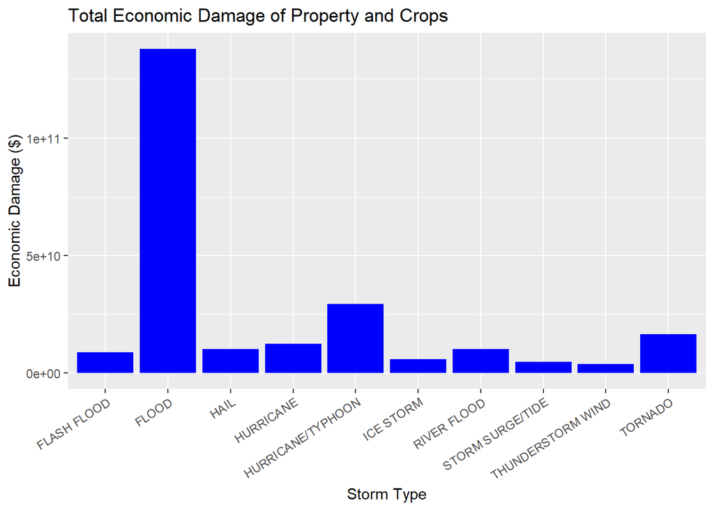

```r
dmg <- ggplot(ecodmg10, aes(EVTYPE, TOTAL))
dmg + geom_bar(stat = "identity", fill = "blue") + theme(axis.text.x=element_text(angle=33, hjust = 1)) + labs(title = "Total Economic Damage of Property and Crops", x= "Storm Type", y = "Economic Damage ($)")
```